# Clase 4.0 Análisis — Soluciones

Estadística y Manejo de Datos con R (EMDR) — Virtual

## Recuerda cargar las bibliotecas requeridas

```r
library(dplyr) # Ejercicios varios
library(magrittr) # Ejercicios varios
library(tidyr) # Ejercicios varios
library(multcomp) # Ejercicios GLM
library(lmerTest) # Ejercicios GLMM
library(FactoMineR) # Ejercicios Componentes Principales
library(factoextra) # Ejercicios Componentes Principales
library(cluster) # Ejercicios Agrupamiento o clustering
```

## Estadística inferencial con datos de `sleep` y `warpbreaks`

## Estadística inferencial: Ejercicios

- Solución (1era parte)

```r
?sleep
head(sleep)
```

```r
t.test(formula = extra ~ group, data = sleep, paired = T)
```

```
##
##  Paired t-test
##
## data:  extra by group
## t = -4.0621, df = 9, p-value = 0.002833
## alternative hypothesis: true difference in means is not equal to 0
## 95 percent confidence interval:
##  -2.4598858 -0.7001142
## sample estimates:
## mean of the differences
##                   -1.58
```

## Estadística inferencial: Ejercicios

- Solución (2nda parte)

```r
?warpbreaks
```

```r
aov.wbrks <- aov(breaks ~ wool*tension, data = warpbreaks)
summary(aov.wbrks)
```

```
##              Df Sum Sq Mean Sq F value   Pr(>F)
## wool          1    451   450.7   3.765 0.058213 .
## tension       2   2034  1017.1   8.498 0.000693 ***
## wool:tension  2   1003   501.4   4.189 0.021044 *
## Residuals    48   5745   119.7
## ---
## Signif. codes:  0 '***' 0.001 '**' 0.01 '*' 0.05 '.' 0.1 ' ' 1
```

## Estadística inferencial: Ejercicios

- Solución (3era parte)

```r
poshoc.wbrks <- TukeyHSD(aov.wbrks)
poshoc.wbrks$wool
```

```
##          diff       lwr       upr      p adj
## B-A -5.777778 -11.76458 0.2090243 0.05821298
```

```r
poshoc.wbrks$tension
```

```
##           diff       lwr       upr        p adj
## M-L -10.000000 -18.81965 -1.180353 0.0228553984
## H-L -14.722222 -23.54187 -5.902575 0.0005595392
## H-M  -4.722222 -13.54187  4.097425 0.4049441962
```

## Estadística inferencial: Ejercicios

- Solución (4ta parte)

```r
poshoc.wbrks$`wool:tension` %>%
  data.frame() %>%
  cbind(rn = row.names(.), .) %>%
  filter(p.adj < 0.05)
```

```
##              rn      diff       lwr        upr        p.adj
## B:L-A:L B:L-A:L -16.33333 -31.63966  -1.027012 0.0302143219
## A:M-A:L A:M-A:L -20.55556 -35.86188  -5.249234 0.0029580438
## B:M-A:L B:M-A:L -15.77778 -31.08410  -0.471456 0.0398172376
## A:H-A:L A:H-A:L -20.00000 -35.30632  -4.693678 0.0040954674
## B:H-A:L B:H-A:L -25.77778 -41.08410 -10.471456 0.0001136469
```

## Modelos con datos de `swiss`

## Modelos: Ejercicios

- Solución (1era parte)

```r
mod1 <- lm(Fertility ~ Infant.Mortality + Examination + Agriculture +
             Education + Catholic, data = swiss)
summary(mod1)
```

```
##
## Call:
## lm(formula = Fertility ~ Infant.Mortality + Examination + Agriculture +
##     Education + Catholic, data = swiss)
##
## Residuals:
##      Min       1Q   Median       3Q      Max
## -15.2743  -5.2617   0.5032   4.1198  15.3213
##
## Coefficients:
##                  Estimate Std. Error t value Pr(>|t|)
## (Intercept)      66.91518   10.70604   6.250 1.91e-07 ***
## Infant.Mortality  1.07705    0.38172   2.822  0.00734 **
## Examination      -0.25801    0.25388  -1.016  0.31546
## Agriculture      -0.17211    0.07030  -2.448  0.01873 *
## Education        -0.87094    0.18303  -4.758 2.43e-05 ***
## Catholic          0.10412    0.03526   2.953  0.00519 **
## ---
## Signif. codes:  0 '***' 0.001 '**' 0.01 '*' 0.05 '.' 0.1 ' ' 1
##
## Residual standard error: 7.165 on 41 degrees of freedom
## Multiple R-squared:  0.7067, Adjusted R-squared:  0.671
## F-statistic: 19.76 on 5 and 41 DF,  p-value: 5.594e-10
```

## Modelos: Ejercicios

- Solución (2nda parte)

```r
mod2 <- lm(Fertility ~ Infant.Mortality + Agriculture + Education +
             Catholic, data = swiss)
summary(mod2)
```

```
##
## Call:
## lm(formula = Fertility ~ Infant.Mortality + Agriculture + Education +
##     Catholic, data = swiss)
##
## Residuals:
##      Min       1Q   Median       3Q      Max
## -14.6765  -6.0522   0.7514   3.1664  16.1422
##
## Coefficients:
##                  Estimate Std. Error t value Pr(>|t|)
## (Intercept)      62.10131    9.60489   6.466 8.49e-08 ***
## Infant.Mortality  1.07844    0.38187   2.824  0.00722 **
## Agriculture      -0.15462    0.06819  -2.267  0.02857 *
## Education        -0.98026    0.14814  -6.617 5.14e-08 ***
## Catholic          0.12467    0.02889   4.315 9.50e-05 ***
## ---
## Signif. codes:  0 '***' 0.001 '**' 0.01 '*' 0.05 '.' 0.1 ' ' 1
##
## Residual standard error: 7.168 on 42 degrees of freedom
## Multiple R-squared:  0.6993, Adjusted R-squared:  0.6707
## F-statistic: 24.42 on 4 and 42 DF,  p-value: 1.717e-10
```

## Modelos: Ejercicios

- Solución (3era parte)

```r
anova(mod1, mod2)
```

```
## Analysis of Variance Table
##
## Model 1: Fertility ~ Infant.Mortality + Examination + Agriculture + Education +
##     Catholic
## Model 2: Fertility ~ Infant.Mortality + Agriculture + Education + Catholic
##   Res.Df    RSS Df Sum of Sq      F Pr(>F)
## 1     41 2105.0
## 2     42 2158.1 -1   -53.027 1.0328 0.3155
```

## Modelos: Ejercicios

- Solución (3era parte)

```r
mod3 <- lm(Fertility ~ Infant.Mortality + Education +
             Catholic, data = swiss)
summary(mod3)
```

```
##
## Call:
## lm(formula = Fertility ~ Infant.Mortality + Education + Catholic,
##     data = swiss)
##
## Residuals:
##      Min       1Q   Median       3Q      Max
## -14.4781  -5.4403  -0.5143   4.1568  15.1187
##
## Coefficients:
##                  Estimate Std. Error t value Pr(>|t|)
## (Intercept)      48.67707    7.91908   6.147 2.24e-07 ***
## Infant.Mortality  1.29615    0.38699   3.349  0.00169 **
## Education        -0.75925    0.11680  -6.501 6.83e-08 ***
## Catholic          0.09607    0.02722   3.530  0.00101 **
## ---
## Signif. codes:  0 '***' 0.001 '**' 0.01 '*' 0.05 '.' 0.1 ' ' 1
##
## Residual standard error: 7.505 on 43 degrees of freedom
## Multiple R-squared:  0.6625, Adjusted R-squared:  0.639
## F-statistic: 28.14 on 3 and 43 DF,  p-value: 3.15e-10
```

## Modelos: Ejercicios

- Solución (3era parte)

```r
anova(mod2, mod3)
```

```
## Analysis of Variance Table
##
## Model 1: Fertility ~ Infant.Mortality + Agriculture + Education + Catholic
## Model 2: Fertility ~ Infant.Mortality + Education + Catholic
##   Res.Df    RSS Df Sum of Sq      F  Pr(>F)
## 1     42 2158.1
## 2     43 2422.2 -1   -264.18 5.1413 0.02857 *
## ---
## Signif. codes:  0 '***' 0.001 '**' 0.01 '*' 0.05 '.' 0.1 ' ' 1
```

## Modelos: Ejercicios

- Solución (4ta parte)

```r
step(mod1) # automatiza el proceso de remover variables y revisar el efecto
```

## Modelos Lineales Generalizados con `hsb` del paquete `descriptr`

## GLM: Ejercicios

- Solución (1era parte)

```r
library(descriptr)
```

```r
?hsb
```

```r
head(hsb)
```

```
##    id female race ses schtyp prog read write math science socst
## 1  70      0    4   1      1    1   57    52   41      47    57
## 2 121      1    4   2      1    3   68    59   53      63    61
## 3  86      0    4   3      1    1   44    33   54      58    31
## 4 141      0    4   3      1    3   63    44   47      53    56
## 5 172      0    4   2      1    2   47    52   57      53    61
## 6 113      0    4   2      1    2   44    52   51      63    61
```

## GLM: Ejercicios

- Solución (2nda parte)

```r
# cambiar manualmente el valor de la variable de respuesta
glm.read <- glm(read ~ female + race + ses + schtyp + prog, data = hsb)
summary(glm.read)
```

```
##
## Call:
## glm(formula = read ~ female + race + ses + schtyp + prog, data = hsb)
##
## Deviance Residuals:
##      Min        1Q    Median        3Q       Max
## -20.7785   -6.3335   -0.1431    6.0284   20.6762
##
## Coefficients:
##             Estimate Std. Error t value Pr(>|t|)
## (Intercept)  44.1760     2.4777  17.830  < 2e-16 ***
## female1      -0.7421     1.3034  -0.569 0.569783
## race2         3.5716     3.3355   1.071 0.285622
## race3         0.4647     2.7477   0.169 0.865872
## race4         5.6720     2.0314   2.792 0.005772 **
## ses2          1.8983     1.7182   1.105 0.270641
## ses3          4.3395     1.9119   2.270 0.024349 *
## schtyp2      -1.0406     1.8111  -0.575 0.566253
## prog2         5.5910     1.6488   3.391 0.000847 ***
## prog3        -3.3022     1.8954  -1.742 0.083090 .
## ---
## Signif. codes:  0 '***' 0.001 '**' 0.01 '*' 0.05 '.' 0.1 ' ' 1
##
## (Dispersion parameter for gaussian family taken to be 80.81652)
##
##     Null deviance: 20919  on 199  degrees of freedom
## Residual deviance: 15355  on 190  degrees of freedom
## AIC: 1457.8
##
## Number of Fisher Scoring iterations: 2
```

## GLM: Ejercicios

- Solución (3era parte)

```r
# suma de todos los puntajes
glm.all <- glm((read+write+math+science+socst) ~ female + race + ses + schtyp + prog, data = hsb)
summary(glm.all)
```

```
##
## Call:
## glm(formula = (read + write + math + science + socst) ~ female +
##     race + ses + schtyp + prog, data = hsb)
##
## Deviance Residuals:
##     Min       1Q   Median       3Q      Max
## -94.050  -20.931   -1.445   26.559   99.629
##
## Coefficients:
##             Estimate Std. Error t value Pr(>|t|)
## (Intercept) 221.8452     9.0899  24.406  < 2e-16 ***
## female1       3.4800     4.7818   0.728 0.467664
## race2        24.9665    12.2369   2.040 0.042708 *
## race3         0.3997    10.0805   0.040 0.968411
## race4        27.4641     7.4528   3.685 0.000298 ***
## ses2         11.0779     6.3036   1.757 0.080462 .
## ses3         21.2478     7.0143   3.029 0.002793 **
## schtyp2      -3.8433     6.6444  -0.578 0.563656
## prog2        21.4929     6.0489   3.553 0.000480 ***
## prog3       -21.0166     6.9538  -3.022 0.002854 **
## ---
## Signif. codes:  0 '***' 0.001 '**' 0.01 '*' 0.05 '.' 0.1 ' ' 1
##
## (Dispersion parameter for gaussian family taken to be 1087.751)
##
##     Null deviance: 332175  on 199  degrees of freedom
## Residual deviance: 206673  on 190  degrees of freedom
## AIC: 1977.7
##
## Number of Fisher Scoring iterations: 2
```

## GLM: Ejercicios

- Solución (4ta parte)

```r
hsb.all <- hsb %>% mutate(all = rowMeans(dplyr::select(.,read,write,math,science,socst)))
# promedio de todos los puntajes
glm.all <- glm(all ~ female + race + ses + schtyp + prog, data = hsb.all)
summary(glm.all)
```

```
##
## Call:
## glm(formula = all ~ female + race + ses + schtyp + prog, data = hsb.all)
##
## Deviance Residuals:
##     Min       1Q   Median       3Q      Max
## -18.810   -4.186   -0.289    5.312   19.926
##
## Coefficients:
##             Estimate Std. Error t value Pr(>|t|)
## (Intercept) 44.36905    1.81798  24.406  < 2e-16 ***
## female1      0.69600    0.95637   0.728 0.467664
## race2        4.99331    2.44739   2.040 0.042708 *
## race3        0.07994    2.01610   0.040 0.968411
## race4        5.49282    1.49056   3.685 0.000298 ***
## ses2         2.21559    1.26073   1.757 0.080462 .
## ses3         4.24956    1.40286   3.029 0.002793 **
## schtyp2     -0.76867    1.32888  -0.578 0.563656
## prog2        4.29858    1.20978   3.553 0.000480 ***
## prog3       -4.20332    1.39076  -3.022 0.002854 **
## ---
## Signif. codes:  0 '***' 0.001 '**' 0.01 '*' 0.05 '.' 0.1 ' ' 1
##
## (Dispersion parameter for gaussian family taken to be 43.51003)
##
##     Null deviance: 13287.0  on 199  degrees of freedom
## Residual deviance:  8266.9  on 190  degrees of freedom
## AIC: 1333.9
##
## Number of Fisher Scoring iterations: 2
```

## GLM: Ejercicios

- Solución (5ta parte)

```r
step(glm.all)
```

```
## Start:  AIC=1333.92
## all ~ female + race + ses + schtyp + prog
##
##          Df Deviance    AIC
## - schtyp  1   8281.5 1332.3
## - female  1   8289.9 1332.5
## <none>        8266.9 1333.9
## - ses     2   8668.7 1339.4
## - race    3   9183.1 1348.9
## - prog    2  10515.3 1378.0
##
## Step:  AIC=1332.27
## all ~ female + race + ses + prog
##
##          Df Deviance    AIC
## - female  1   8303.1 1330.8
## <none>        8281.5 1332.3
## - ses     2   8673.3 1337.5
## - race    3   9189.7 1347.1
## - prog    2  10556.1 1376.8
##
## Step:  AIC=1330.79
## all ~ race + ses + prog
##
##        Df Deviance    AIC
## <none>      8303.1 1330.8
## - ses   2   8677.9 1335.6
## - race  3   9225.0 1345.8
## - prog  2  10587.2 1375.4
```

```
##
## Call:  glm(formula = all ~ race + ses + prog, data = hsb.all)
##
## Coefficients:
## (Intercept)        race2        race3        race4         ses2         ses3
##     44.7312       5.2324       0.1677       5.5284       1.9730       4.0399
##       prog2        prog3
##      4.2828      -4.0801
##
## Degrees of Freedom: 199 Total (i.e. Null);  192 Residual
## Null Deviance:       13290
## Residual Deviance: 8303  AIC: 1331
```

## GLM: Ejercicios

- Solución (6ta parte)

```r
boxplot(all ~ race, data = hsb.all)
boxplot(all ~ ses, data = hsb.all)
boxplot(all ~ prog, data = hsb.all)
```

[output not shown]

## Modelos Lineales Generalizados Mixtos con datos de `CO2`

## GLMM: Ejercicios

- Solución (1er parte)

```r
?CO2
head(CO2)
str(CO2)
CO2$Type
CO2$Treatment
CO2$Plant
CO2 %>% filter(Treatment == "chilled")
```

## GLMM: Ejercicios

- Solución (2nda parte)

Type >> Treatment >> Plant

## GLMM: Ejercicios

- Solución (3era parte)

```r
lmm.co2 <- lmer(uptake ~ conc + Type*Treatment + 1|Type/Treatment/Plant, data = CO2)
summary(lmm.co2)
```

```
## Linear mixed model fit by REML. t-tests use Satterthwaite's method [
## lmerModLmerTest]
## Formula: uptake ~ conc + Type * Treatment + 1 | Type/Treatment/Plant
##    Data: CO2
##
## REML criterion at convergence: 543.9
##
## Scaled residuals:
##     Min      1Q  Median      3Q     Max
## -2.7387 -0.5171  0.0638  0.6286  1.7398
##
## Random effects:
##  Groups                 Name                             Variance  Std.Dev.
##  Plant:(Treatment:Type) (Intercept)                      1.648e-01 0.4059832
##                         conc                             6.178e-08 0.0002486
##                         TypeMississippi                  8.064e-02 0.2839781
##                         Treatmentchilled                 6.531e-01 0.8081439
##                         TypeMississippi:Treatmentchilled 6.082e+00 2.4661086
##  Treatment:Type         (Intercept)                      2.139e+00 1.4625054
##                         conc                             8.216e-06 0.0028663
##                         TypeMississippi                  3.056e+00 1.7480754
##                         Treatmentchilled                 4.966e+00 2.2285236
##                         TypeMississippi:Treatmentchilled 2.296e+01 4.7915595
##  Type                   (Intercept)                      3.216e+01 5.6708689
##                         conc                             3.239e-04 0.0179975
##                         TypeMississippi                  1.640e+00 1.2806859
##                         Treatmentchilled                 3.471e-01 0.5891868
##                         TypeMississippi:Treatmentchilled 2.118e+01 4.6024844
##  Residual                                                3.186e+01 5.6443789
##  Corr
##
##   1.00
##  -0.97 -0.97
##   0.95  0.95 -0.97
##  -0.31 -0.31  0.33 -0.38
##
##  -1.00
##  -0.98  0.98
##  -0.66  0.66  0.60
##  -0.28  0.28  0.24  0.11
##
##   1.00
##  -0.80 -0.80
##  -0.90 -0.90  0.62
##  -0.04 -0.04  0.05 -0.01
##
## Number of obs: 84, groups:
## Plant:(Treatment:Type), 12; Treatment:Type, 4; Type, 2
##
## Fixed effects:
##             Estimate Std. Error     df t value Pr(>|t|)
## (Intercept)   16.751      1.884  1.332   8.891   0.0379 *
## ---
## Signif. codes:  0 '***' 0.001 '**' 0.01 '*' 0.05 '.' 0.1 ' ' 1
## convergence code: 0
## boundary (singular) fit: see ?isSingular
```

## GLMM: Ejercicios

- Solución (4ta parte)

```r
library(ggplot2)
```

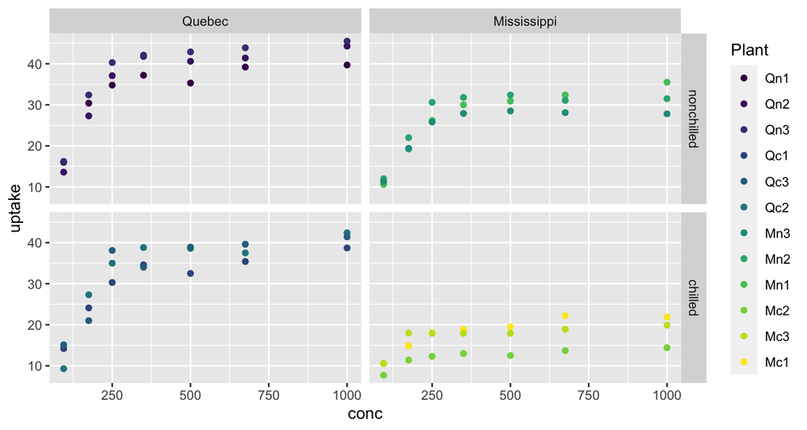

```r
ggplot(CO2, aes(x=conc, y=uptake, color=Plant)) + geom_point() + facet_grid(Treatment~Type)
```

## Análisis agregativos con `wine` del paquete `FactoMineR`

## Componentes principales: Ejercicios

- Solución (1era parte)

```r
data(wine)
res.pca <- PCA(wine %>% dplyr::select(-Label,-Soil), scale.unit = T, graph = F)
res.pca
```

```
## **Results for the Principal Component Analysis (PCA)**
## The analysis was performed on 21 individuals, described by 29 variables
## *The results are available in the following objects:
##
##    name               description
## 1  "$eig"             "eigenvalues"
## 2  "$var"             "results for the variables"
## 3  "$var$coord"       "coord. for the variables"
## 4  "$var$cor"         "correlations variables - dimensions"
## 5  "$var$cos2"        "cos2 for the variables"
## 6  "$var$contrib"     "contributions of the variables"
## 7  "$ind"             "results for the individuals"
## 8  "$ind$coord"       "coord. for the individuals"
## 9  "$ind$cos2"        "cos2 for the individuals"
## 10 "$ind$contrib"     "contributions of the individuals"
## 11 "$call"            "summary statistics"
## 12 "$call$centre"     "mean of the variables"
## 13 "$call$ecart.type" "standard error of the variables"
## 14 "$call$row.w"      "weights for the individuals"
## 15 "$call$col.w"      "weights for the variables"
```

## Componentes principales: Ejercicios

- Solución (2nda parte)

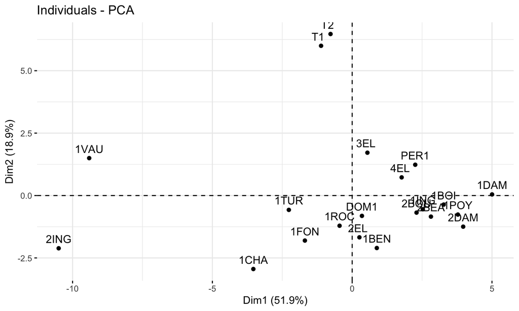

```r
fviz_pca_ind(res.pca)
```

## Componentes principales: Ejercicios

- Solución (3ra parte)

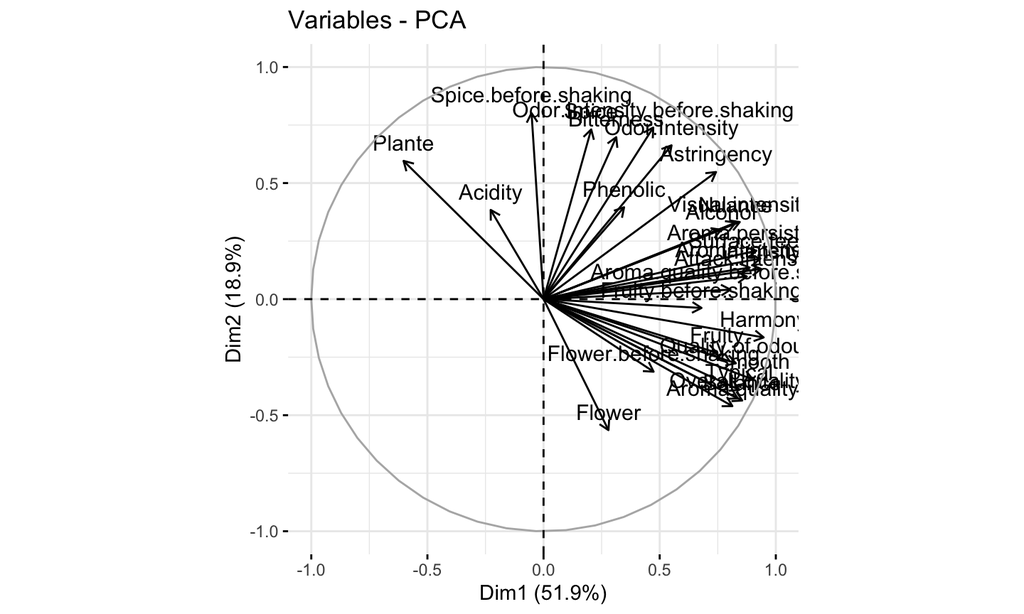

```r
fviz_pca_var(res.pca)
```